# EDA_ASSIGNMENT

Shaik Salma Aga

2023-02-12

Step 1 : Need to load library tidyverse package

```r
library(tidyverse)
```

Step 2: Load the iris dataset and assign it into indata variable

```r
indata <- iris
```

Step 3: Check for dimensions

```r
dim(indata)
```

```
## [1] 150   5
```

From the above output we can see that there are 150 rows and 5 columns.

Step 4 : Need to check first 6th rows by using head() function and for checking the last 6th columns we need to use a function called tail()

```r
head(indata)
```

```
##   Sepal.Length Sepal.Width Petal.Length Petal.Width Species
## 1          5.1         3.5          1.4         0.2  setosa
## 2          4.9         3.0          1.4         0.2  setosa
## 3          4.7         3.2          1.3         0.2  setosa
## 4          4.6         3.1          1.5         0.2  setosa
## 5          5.0         3.6          1.4         0.2  setosa
## 6          5.4         3.9          1.7         0.4  setosa
```

```r
tail(indata)
```

```
##     Sepal.Length Sepal.Width Petal.Length Petal.Width   Species
## 145          6.7         3.3          5.7         2.5 virginica
## 146          6.7         3.0          5.2         2.3 virginica
## 147          6.3         2.5          5.0         1.9 virginica
## 148          6.5         3.0          5.2         2.0 virginica
## 149          6.2         3.4          5.4         2.3 virginica
## 150          5.9         3.0          5.1         1.8 virginica
```

Step 5 : Check the iris dataset is a data frame or not, for checking it we need to use a function is.data.frame()

```r
is.data.frame(indata)
```

```
## [1] TRUE
```

We received an output as TRUE, so it is a data frame

Step 6 : Check the iris dataset is a tibble or not for that we need to use a function as_tibble for checking it

```r
is_tibble(indata)
```

```
## [1] FALSE
```

We can see that the output is False, it means the iris dataset is not a tibble.

Step 7 : Convert it into a tibble by using a funtion called as_tibble

```r
indata <- as_tibble(indata)
is_tibble(indata)
```

```
## [1] TRUE
```

We have received an output as True, after converting the iris dataset into a tibble.

Step 8 : Need to check data quality

1. Need to Calculate of sum of the values of each Column by using a function called colSums.

```r
colSums(is.na(indata))
```

```
## Sepal.Length  Sepal.Width Petal.Length  Petal.Width      Species
##            0            0            0            0            0
```

We got an output as 0, it means there are no missing values in each column

2. Check for outliers by using boxplot()

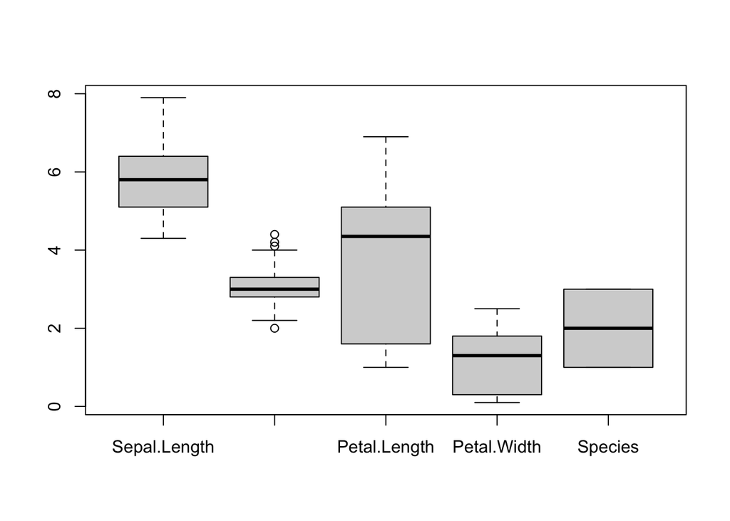

```r
boxplot(indata)
```

From the above output we can see that outliers are present in Sepal.Width

Step 9 : Check interquartile range of Sepal.Width by using a formula IQR = Q3-Q1 , where Q3 = third quartile and Q1 = first quartile

From the summary of data we know that Q3 value is 3.3 and Q1 value is 2.8

```r
Q3 <- 3.3
Q1 <- 2.8
Q3-Q1
```

```
## [1] 0.5
```

```r
IQR <- Q3-Q1
IQR
```

```
## [1] 0.5
```

After calculating it we received IQR value as 0.5

Step 10 : Check for Tmin value by using a formula Tmin = Q1-(1.5*IQR)

```r
Tmin <- Q1-(1.5*IQR)
Tmin
```

```
## [1] 2.05
```

where Tmin value is 2.05

Step 11 : Check for Tmax value by using a formula Tmax = Q3+(1.5*IQR)

```r
Tmax <- Q3+(1.5*IQR)
Tmax
```

```
## [1] 4.05
```

We received Tmax value as 4.05

Step 12 :Need to find outliers of Sepal.Width

```r
x <- indata$Sepal.Width
y<-x[which(x < 2.05 | x > 4.05)]
y
```

```
## [1] 4.4 4.1 4.2 2.0
```

From the above output we can see that there are 4 outliers in which one is below tmin value and others are above tmax values.

Step 13 : Need to remove outliers

```r
z<-x[which(x > 2.05 & x < 4.05)]
z
```

```
##   [1] 3.5 3.0 3.2 3.1 3.6 3.9 3.4 3.4 2.9 3.1 3.7 3.4 3.0 3.0 4.0 3.9 3.5 3.8
##  [19] 3.8 3.4 3.7 3.6 3.3 3.4 3.0 3.4 3.5 3.4 3.2 3.1 3.4 3.1 3.2 3.5 3.6 3.0
##  [37] 3.4 3.5 2.3 3.2 3.5 3.8 3.0 3.8 3.2 3.7 3.3 3.2 3.2 3.1 2.3 2.8 2.8 3.3
##  [55] 2.4 2.9 2.7 3.0 2.2 2.9 2.9 3.1 3.0 2.7 2.2 2.5 3.2 2.8 2.5 2.8 2.9 3.0
##  [73] 2.8 3.0 2.9 2.6 2.4 2.4 2.7 2.7 3.0 3.4 3.1 2.3 3.0 2.5 2.6 3.0 2.6 2.3
##  [91] 2.7 3.0 2.9 2.9 2.5 2.8 3.3 2.7 3.0 2.9 3.0 3.0 2.5 2.9 2.5 3.6 3.2 2.7
## [109] 3.0 2.5 2.8 3.2 3.0 3.8 2.6 2.2 3.2 2.8 2.8 2.7 3.3 3.2 2.8 3.0 2.8 3.0
## [127] 2.8 3.8 2.8 2.8 2.6 3.0 3.4 3.1 3.0 3.1 3.1 3.1 2.7 3.2 3.3 3.0 2.5 3.0
## [145] 3.4 3.0
```

Step 14 : Plot a boxplot and check outliers are there or not

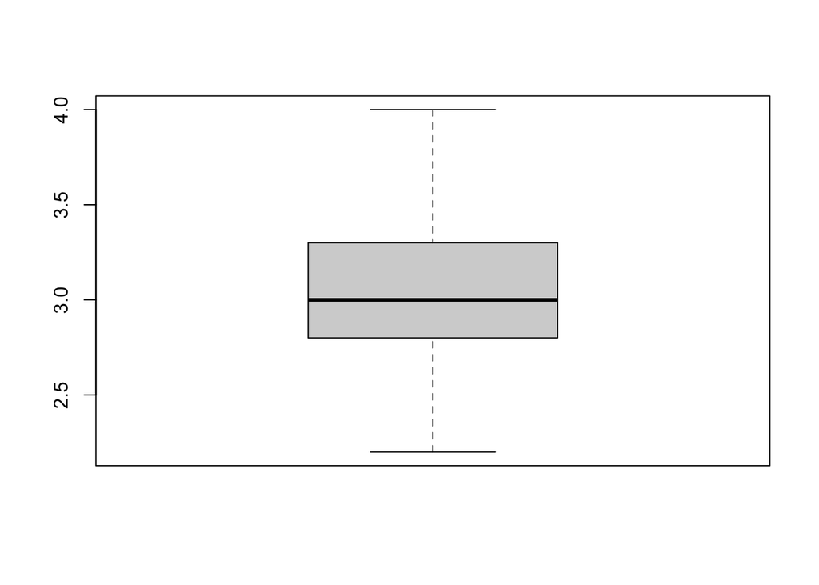

```r
boxplot(z)
```

From the above graph we can see that we have removed the outliers.

Step 15 : Need to check description of the data

1. Check how many observations are present, and we need to use a function nrow()

```r
nrow(indata)
```

```
## [1] 150
```

There are 150 observations are present in iris dataset.

2. Check are there any variables present in iris dataset for that we have to use a function ncol()

```r
ncol(indata)
```

```
## [1] 5
```

It has 5 variables.

3. Need to check how many numeric variables and categorical are there?

```r
str(indata)
```

```
## tibble [150 × 5] (S3: tbl_df/tbl/data.frame)
##  $ Sepal.Length: num [1:150] 5.1 4.9 4.7 4.6 5 5.4 4.6 5 4.4 4.9 ...
##  $ Sepal.Width : num [1:150] 3.5 3 3.2 3.1 3.6 3.9 3.4 3.4 2.9 3.1 ...
##  $ Petal.Length: num [1:150] 1.4 1.4 1.3 1.5 1.4 1.7 1.4 1.5 1.4 1.5 ...
##  $ Petal.Width : num [1:150] 0.2 0.2 0.2 0.2 0.2 0.4 0.3 0.2 0.2 0.1 ...
##  $ Species     : Factor w/ 3 levels "setosa","versicolor",..: 1 1 1 1 1 1 1 1 1 1 ...
```

From the above output we can see that there are 4 numeric variables and one categorical variable Where Numeric variables are Sepal.Length,Sepal.Width,Petal.Length and Petal.Width Categorical variable is Species

Step 16 : Variables description

1. check what data type it is?

```r
typeof(indata)
```

```
## [1] "list"
```

Output : It is a list

2. Need check names of the column

```r
colnames(indata)
```

```
## [1] "Sepal.Length" "Sepal.Width"  "Petal.Length" "Petal.Width"  "Species"
```

From the output we can see column names

3. Check which type of column it is?

```r
sapply(colnames(indata), function(x) class(indata[[x]]))
```

```
## Sepal.Length  Sepal.Width Petal.Length  Petal.Width      Species
##    "numeric"    "numeric"    "numeric"    "numeric"     "factor"
```

4. Check for missing values by using a function as.na

```r
sum(is.na(indata))
```

```
## [1] 0
```

From the above output we received a number “Zero” it means there are no missing values set in iris dataset.

5. Are there any duplicate rows?

```r
sum(duplicated(indata))
```

```
## [1] 1
```

From the above output we can see there is one duplicate row.

6. Removing duplicate value

```r
indata2 <- indata[!duplicated(indata),]
sum(duplicated(indata2))
```

```
## [1] 0
```

We have received an output as zero it means thre are no duplicate value.

Step 17 : Compute summary statistics (mean, median, mode, standard deviation, variance, range).

```r
summary(indata)
```

```
##   Sepal.Length    Sepal.Width     Petal.Length    Petal.Width
##  Min.   :4.300   Min.   :2.000   Min.   :1.000   Min.   :0.100
##  1st Qu.:5.100   1st Qu.:2.800   1st Qu.:1.600   1st Qu.:0.300
##  Median :5.800   Median :3.000   Median :4.350   Median :1.300
##  Mean   :5.843   Mean   :3.057   Mean   :3.758   Mean   :1.199
##  3rd Qu.:6.400   3rd Qu.:3.300   3rd Qu.:5.100   3rd Qu.:1.800
##  Max.   :7.900   Max.   :4.400   Max.   :6.900   Max.   :2.500
##        Species
##  setosa    :50
##  versicolor:50
##  virginica :50
##
##
##
```

From the above output we can see mean and median but we can also calculate mean and median by using statistics functions

Step 18 : Calculating the mode variables

```r
find_mode <- function(x)
{
  u <- unique(x)
  tab <- tabulate(match(x,u))
  u[tab == max(tab)]
}
```

Step 19 : Calculate Mean of Sepal.Length

```r
Mean_Speal.Length <- indata2$Sepal.Length
mean(Mean_Speal.Length)
```

```
## [1] 5.843624
```

2. Calculate Median of Sepal.Length

```r
Median_Speal.Length <- indata2$Sepal.Length
median(Median_Speal.Length)
```

```
## [1] 5.8
```

3. Calculate of standard deviation Sepal.Length

```r
sd(indata2$Sepal.Length)
```

```
## [1] 0.8308513
```

4. Calculate range of Sepal.Length

```r
range(indata2$Sepal.Length)
```

```
## [1] 4.3 7.9
```

5. Calculate quantile of Sepal.Length

```r
quantile(indata2$Sepal.Length)
```

```
##   0%  25%  50%  75% 100%
##  4.3  5.1  5.8  6.4  7.9
```

6. Calculate Mode of Sepal.Length

```r
find_mode(indata2$Sepal.Length)
```

```
## [1] 5
```

g)Calculate Variance of Sepal.Length

```r
var(indata2$Sepal.Length)
```

```
## [1] 0.6903138
```

From the above output we can see the values of mean, median,mode,standard deviation and range.

Step 20 : a) Calculate Mean of Sepal.Width

```r
Mean_Speal.Width <- indata2$Sepal.Width
mean(Mean_Speal.Width)
```

```
## [1] 3.059732
```

2. Calculate Median of Sepal.Width

```r
Median_Speal.Width <- indata2$Sepal.Width
median(Median_Speal.Width)
```

```
## [1] 3
```

3. Calculate range of Sepal.Width

```r
range(indata2$Sepal.Width)
```

```
## [1] 2.0 4.4
```

4. Calculate Standard deviation of Sepal.Width

```r
sd(indata2$Sepal.Width)
```

```
## [1] 0.4363422
```

5. Calculate Variance of Sepal.Width

```r
var(indata2$Sepal.Width)
```

```
## [1] 0.1903945
```

6. Calculate quantile of Sepal.Width

```r
quantile(indata2$Sepal.Width)
```

```
##   0%  25%  50%  75% 100%
##  2.0  2.8  3.0  3.3  4.4
```

g)Calculate Mode of Sepal.Width

```r
find_mode(indata2$Sepal.Width)
```

```
## [1] 3
```

From the above output we can see the values of mean, median,mode,standard deviation and range

Step 20 : a) Calculate Mean of Petal.Length

```r
Mean_Petal.Length <- indata2$Petal.Length
mean(Mean_Petal.Length)
```

```
## [1] 3.748993
```

2. Calculate Median of Petal.Length

```r
Median_Petal.Length <- indata2$Petal.Length
median(Median_Petal.Length)
```

```
## [1] 4.3
```

3. Calculate range of Petal.Length

```r
range(indata2$Petal.Length)
```

```
## [1] 1.0 6.9
```

4. Calculate Standard deviation of Petal.Length

```r
sd(indata2$Petal.Length)
```

```
## [1] 1.767791
```

```r
quantile(indata2$Sepal.Length)
```

```
##   0%  25%  50%  75% 100%
##  4.3  5.1  5.8  6.4  7.9
```

6. Calculate Variance of Petal.Length

```r
var(indata2$Petal.Length)
```

```
## [1] 3.125083
```

7. Calculate mode of Petal.Length

```r
find_mode(indata2$Petal.Length)
```

```
## [1] 1.4 1.5
```

From the above output we can see the values of mean, median,mode,standard deviation and range

Step 21: a) Calculate mean of Petal.Width

```r
Mean_Petal.Width <- indata2$Petal.Width
mean(Mean_Petal.Width)
```

```
## [1] 1.194631
```

2. Calculate median of Petal.Width

```r
Median_Petal.Width <- indata2$Petal.Width
median(Median_Petal.Width)
```

```
## [1] 1.3
```

3. Calculate range of Petal.Width

```r
range(indata2$Petal.Width)
```

```
## [1] 0.1 2.5
```

4. Calculate standard deviation of Petal.Width

```r
sd(indata2$Petal.Width)
```

```
## [1] 0.7626222
```

5. Calculate quantile of Petal.Width

```r
quantile(indata2$Petal.Width)
```

```
##   0%  25%  50%  75% 100%
##  0.1  0.3  1.3  1.8  2.5
```

6. Calculate variance of Petal.Width

```r
var(indata2$Petal.Width)
```

```
## [1] 0.5815926
```

7. Calculate mode of Petal.Width

```r
find_mode(indata2$Petal.Width)
```

```
## [1] 0.2
```

From the above output we can see the values of mean, median,mode,standard deviation and range.

Step 22: Need to select one categorical variable and compute these statistics on a numeric variable by grouping on a categorical variable

1. Check for the numeric variables

```r
numeric_dataset <- function(Dataset){
nums <- sapply(Dataset, is.numeric)
return(Dataset[ , nums])
  }
iris_num <- numeric_dataset(indata)
str(iris_num)
```

```
## tibble [150 × 4] (S3: tbl_df/tbl/data.frame)
##  $ Sepal.Length: num [1:150] 5.1 4.9 4.7 4.6 5 5.4 4.6 5 4.4 4.9 ...
##  $ Sepal.Width : num [1:150] 3.5 3 3.2 3.1 3.6 3.9 3.4 3.4 2.9 3.1 ...
##  $ Petal.Length: num [1:150] 1.4 1.4 1.3 1.5 1.4 1.7 1.4 1.5 1.4 1.5 ...
##  $ Petal.Width : num [1:150] 0.2 0.2 0.2 0.2 0.2 0.4 0.3 0.2 0.2 0.1 ...
```

From the above output we can see only numeric variables.

2. Calculate the mean by using aggregate function because we have both numerical and categorical variable

```r
aggregatemean <- aggregate(iris_num, by = list(iris$Species), FUN = mean)
colnames(aggregatemean)[1] <- "Species"
aggregatemean
```

```
##      Species Sepal.Length Sepal.Width Petal.Length Petal.Width
## 1     setosa        5.006       3.428        1.462       0.246
## 2 versicolor        5.936       2.770        4.260       1.326
## 3  virginica        6.588       2.974        5.552       2.026
```

We can see the mean of three species which are Setosa, Versicolor, Virginica

3. Calculate the Median

```r
aggregatemedian <- aggregate(iris_num, by = list(iris$Species), FUN = median)
colnames(aggregatemedian)[1] <- "Species"
aggregatemedian
```

```
##      Species Sepal.Length Sepal.Width Petal.Length Petal.Width
## 1     setosa          5.0         3.4         1.50         0.2
## 2 versicolor          5.9         2.8         4.35         1.3
## 3  virginica          6.5         3.0         5.55         2.0
```

We can see the median of three species

4. Calculate the standard deviation

```r
aggregateSD <- aggregate(iris_num, by = list(iris$Species), FUN = sd)
colnames(aggregateSD)[1] <- "Species"
aggregateSD
```

```
##      Species Sepal.Length Sepal.Width Petal.Length Petal.Width
## 1     setosa    0.3524897   0.3790644    0.1736640   0.1053856
## 2 versicolor    0.5161711   0.3137983    0.4699110   0.1977527
## 3  virginica    0.6358796   0.3224966    0.5518947   0.2746501
```

We can see the Standard deviation of three species

5. Calculate the range

```r
aggregateRange <- aggregate(iris_num, by = list(iris$Species), FUN = range)
colnames(aggregateRange)[1] <- "Species"
aggregateRange
```

```
##      Species Sepal.Length.1 Sepal.Length.2 Sepal.Width.1 Sepal.Width.2
## 1     setosa            4.3            5.8           2.3           4.4
## 2 versicolor            4.9            7.0           2.0           3.4
## 3  virginica            4.9            7.9           2.2           3.8
##   Petal.Length.1 Petal.Length.2 Petal.Width.1 Petal.Width.2
## 1            1.0            1.9           0.1           0.6
## 2            3.0            5.1           1.0           1.8
## 3            4.5            6.9           1.4           2.5
```

From the above output we received range value.

Step 23 : Relation between the variables

1. Check the relationship between Sepal.Length and Sepal.Width

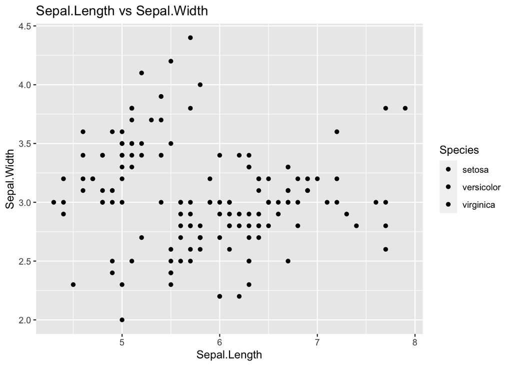

```r
ggplot(data = indata, aes(x = Sepal.Length, y = Sepal.Width, fill = Species)) +geom_point()+ggtitle("Sepal.Length vs Sepal.Width")
```

Output : From the result we cannot see clear relationship between sepal length and Speal width, so for its clear effectiveness I have added geom smooth line in step 24.

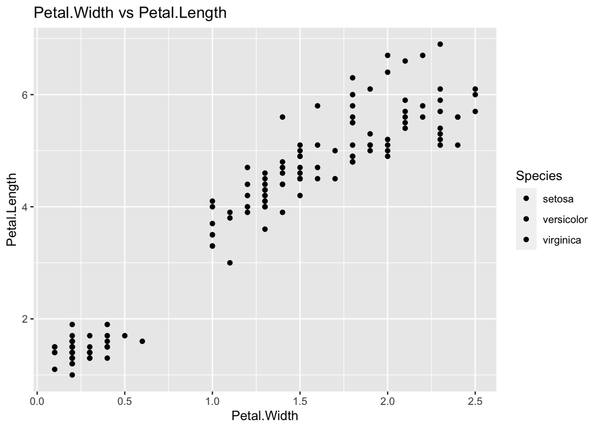

```r
ggplot(indata, aes(x = Petal.Width, y = Petal.Length, fill = Species)) +geom_point()+ggtitle("Petal.Width vs Petal.Length")
```

Step 24 : Plotting the relationship between Sepal length and Sepal width

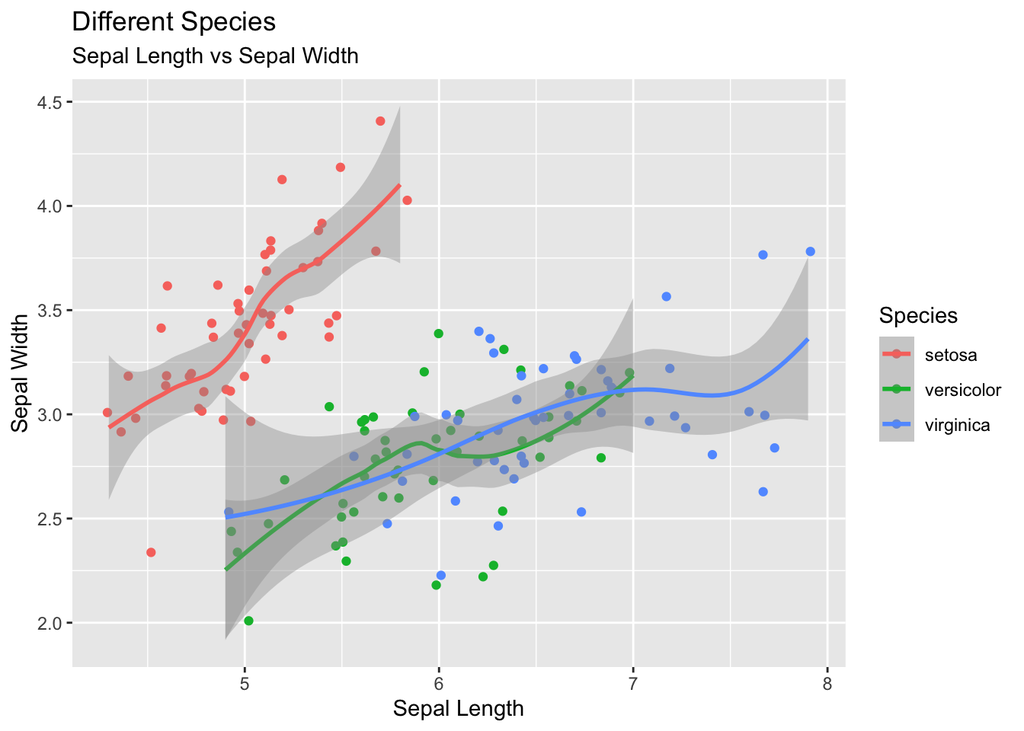

```r
ggplot(data = indata2) + geom_point(mapping = aes(x=Sepal.Length, y =Sepal.Width, color=Species), position = "jitter", alpha = 1) +geom_smooth(mapping = aes(x=Sepal.Length, y =Sepal.Width, color= Species)) +
labs(x = "Sepal Length", y = "Sepal Width", title = "Different Species", subtitle = "Sepal Length vs Sepal Width")
```

Output : From the result we can see Setosa has highest sepal width whereas virginica has the highest sepal length.

Step 25 : Plotting the relationship between Petal Length and Petal Width

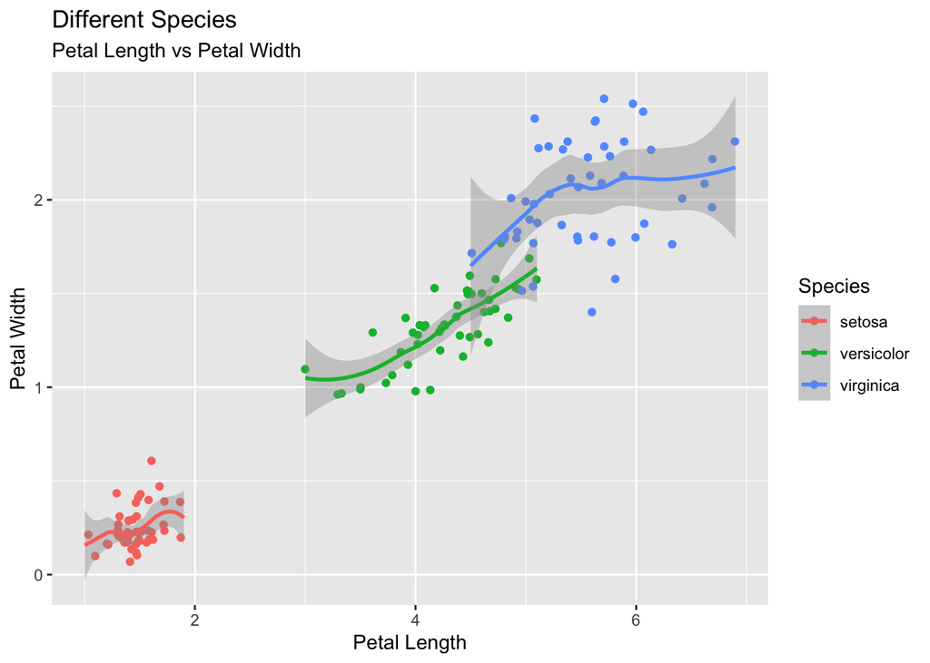

```r
ggplot(data = indata2) + geom_point(mapping = aes(x=Petal.Length, y =Petal.Width, color=Species), position = "jitter", alpha = 1) + geom_smooth(mapping = aes(x=Petal.Length, y =Petal.Width, color= Species)) +labs(x = "Petal Length", y = "Petal Width", title = "Different Species",subtitle = "Petal Length vs Petal Width")
```

Output : From the result we can see Setosa and virginica have some fluctuations whereas petal width is continuously increasing. However, at the end Virginica has highest petal Length.

step 26 : Plotting a bar graph to check the count of each species.

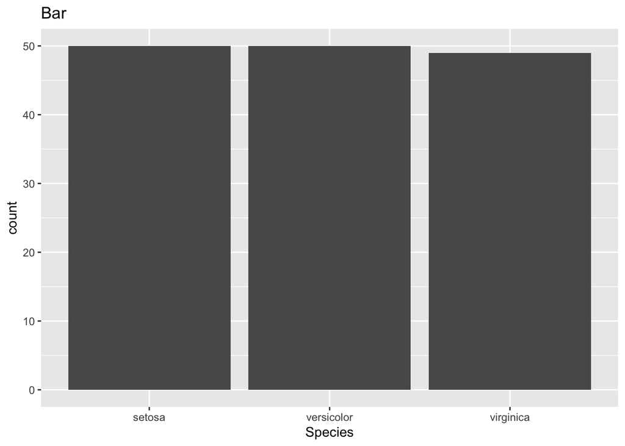

```r
ggplot(data= indata2) + geom_bar(mapping = aes(x=Species))+ggtitle("Species Count")+ggtitle("Bar")
```

Output : From the above graph we can see that Virginica is having less observations as we removed duplicate row.

Step 27 : Using histogram to observe the common values in petal length

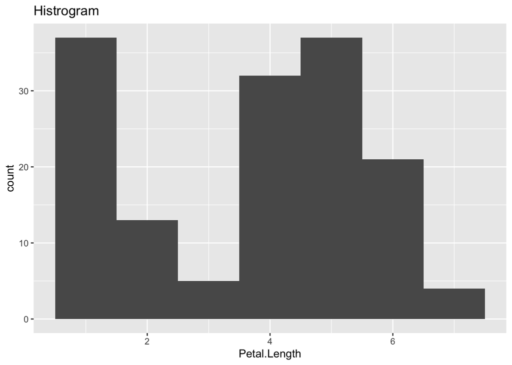

```r
ggplot(data = indata2) + geom_histogram(mapping = aes(x=Petal.Length), binwidth = 1)+ggtitle("Petal Length Count")+ggtitle("Histrogram")
```

Output : From the graph we can observe 4.5 and 1.5 have more than 30 count so we can consider them as common observations.

step 28 : Using histogram to observe the common values in Sepal length

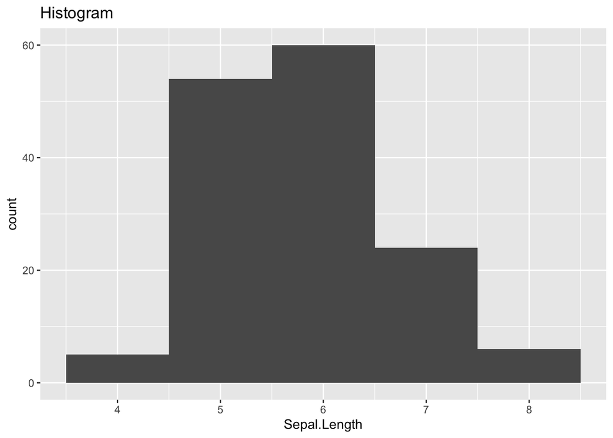

```r
ggplot(data = indata2) + geom_histogram(mapping = aes(x=Sepal.Length),binwidth = 1)+ggtitle("Histogram")
```

Step 29 : Trend graphs

1. Trend graph between Sepal.Length vs Species

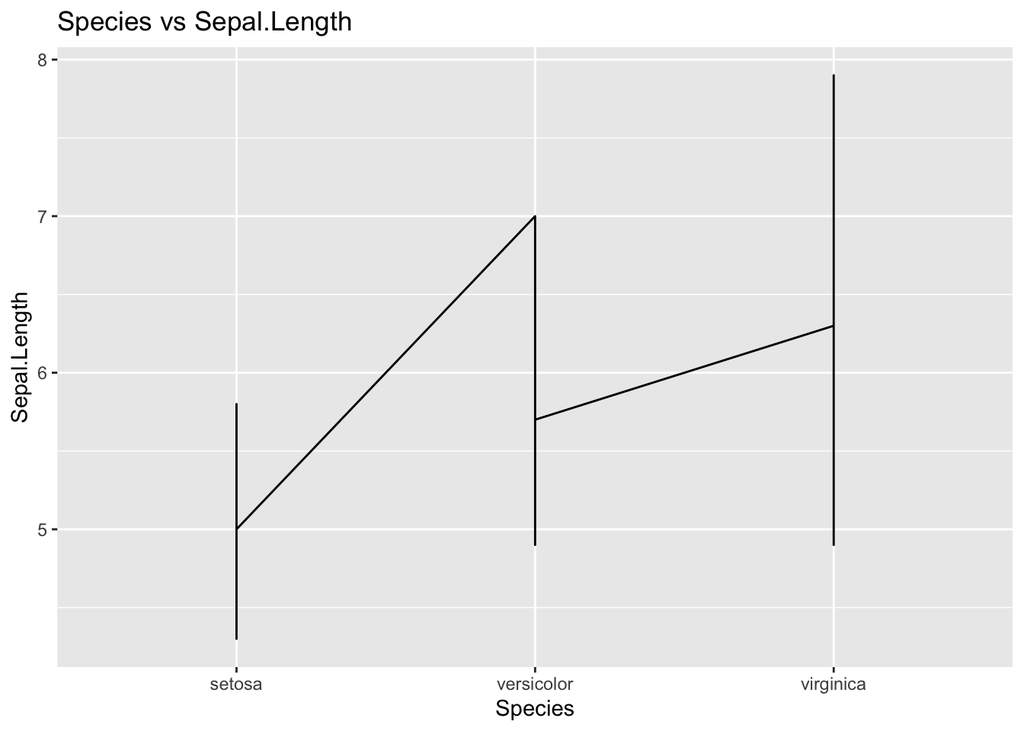

```r
ggplot(data = indata) + geom_line(mapping = aes(x = Species, y = Sepal.Length, group = 1))+ggtitle("Species vs Sepal.Length")
```

2. Trend graph between Sepal.Width vs Species

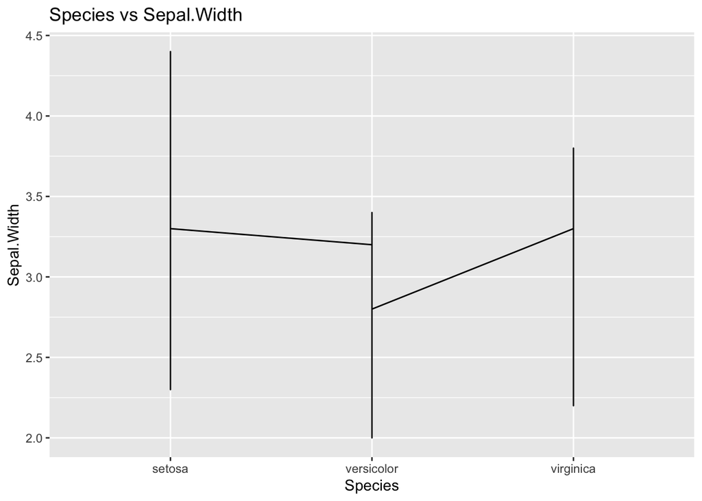

```r
ggplot(data = indata) + geom_line(mapping = aes(x = Species, y = Sepal.Width, group = 1))+ggtitle("Species vs Sepal.Width")
```

Output: From the above graph we can observe Sepal Width of different Species. Setosa has highest Sepal width whereas Versicolor has less Sepal width.

3. Trend graph between Petal.Length vs Species

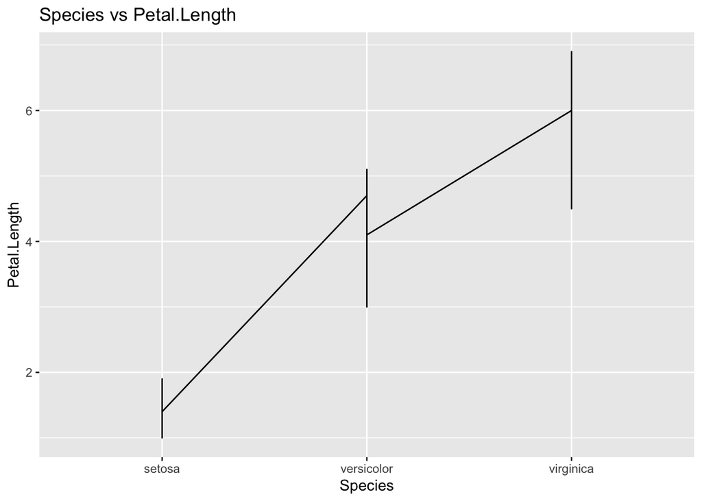

```r
ggplot(data = indata) + geom_line(mapping = aes(x = Species, y = Petal.Length, group = 1))+ggtitle("Species vs Petal.Length")
```

Output : From the above graph we can observe Petal length of different Species. Virginica has highest Petal length whereas Setosa has less Petal length .

4. Trend graph between Petal.Width vs Species

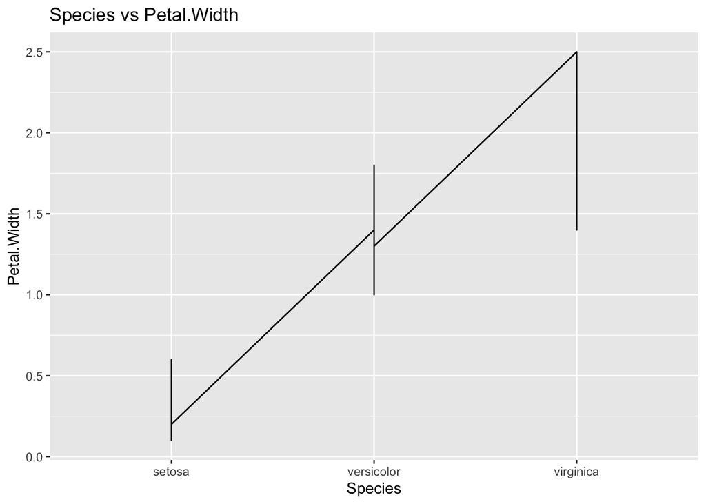

```r
ggplot(data = indata) + geom_line(mapping = aes(x = Species, y = Petal.Width, group = 1))+ggtitle("Species vs Petal.Width")
```

Output : From the above graph we can observe Petal Width of different Species. Virginica has highest Petal width whereas Setosa has less Petal Width .

Step 30 : Summary of insights analysis